# Métodos Numéricos: Trabajo Práctico N°2

## Grupo MN2

- Francois, Matias Santiago
- Gaytan, Joaquin Oscar
- Kammann, Lucas Agustín
- Maselli, Carlos Javier
- Trozzo, Rafael Nicolas

## Introducción

En este trabajo se busca resolver un sistema de ecuaciones diferenciales relacionado a la transferencia inalámbrica de energía con el método de Runge-Kutta-Fehlberg. Para ello, en se realiza en primer lugar una implementación genérica de los métodos de Runge-Kutta, luego se implementa el método particular propuesto y se resuelve el sistema propuesto, validando cada uno de los pasos con simulaciones de problemas ya conocidos. Una vez conocida la salida del sistema, se analizan sus cambios ante variaciones de algunos parámetros del circuito.

## Metodos de Runge-Kutta: Revisión

Los métodos de Runge-Kutta pueden ser expresados de forma genérica a partir de su tabla de Butcher. Esta tabla tiene la siguiente forma:

| $c_1$ | $a_{11}$ | $a_{12}$ | $\cdots$ | $a_{1s}$ |
| --- | --- | --- | --- | --- |
| $c_2$ | $a_{21}$ | $a_{22}$ | $\cdots$ | $a_{2s}$ |
| $\vdots$ | $\vdots$ | $\vdots$ | $\ddots$ | $\vdots$ |
| $c_s$ | $a_{s1}$ | $a_{s1}$ | $\cdots$ | $a_{ss}$ |
|  | $b_1$ | $b_2$ | $\cdots$ | $b_s$ |

Donde:

\begin{equation} c_i = \sum_{j=1}^{s}a_{ij} \end{equation}

De esta forma, el algoritmo queda definido por:

\begin{align} y' &= f(t, y) \\ Y_i &= y_{n-1} + h \sum_{j=1}^{s} a_{ij} f(t_{n-1} + c_jh, Y_j) \\ y_n &= y_{n-1} + h \sum_{i=1}^{s} b_i f(t_{n-1} + c_ih, Y_i) \end{align}

El algoritmo es explícito si $a_{ij} = 0 \,\, \forall_{j>=i}\,$ ya que en ese caso los $Y_i$ se calculan en función de magnitudes conocidas.

A continuación se implementa una **función de Runge-Kutta genérica** que recibe la tabla de Butcher **explícita** deseada.  
Notar que si se cambia el valor de los $b_i$, el calculo de los $Y_i$ no se modifica. Haciendo uso de eso, hay métodos, llamados **embebidos**, que implementan una tabla de Butcher con múltiples filas $\vec{b}$ con distintos coeficientes $b_i$. Para ser compatible con este tipo de métodos, la función recibe un arreglo de vectores $\vec{b}$.  
Para especificar la tabla de Butcher, la función recibe un diccionario con el arreglo de vectores $\vec{b}$ y la matriz A que contiene los $a_{ij}$, a partir de los cuales calcula los $c_i$.

```python
""" DEFINICION DE RUNGE-KUTTA GENERICO """

import numpy as np

def is_number(x):
    """ return True si es un tipo de dato numerico """
    return (type(x) is int) or (type(x) is float) or (type(x) is np.float64)


def rkn(butch_map: dict, f: callable, tn: float, yn: list or float or int, h: float) -> np.ndarray:
    """
      rkn: Implementa un paso del método de Runge-Kutta para una tabla de Butcher
            explícita (a_ij = 0 para j>=i) provista y un sistema de N ecuaciones.
      :param butch_map: diccionario con la tabla de Butcher.
                        Campos: - "A": matriz de 's' x 's' con los a_ij, debe ser
                                        triangular inferior con diagonal de 0s.
                                - "b": arreglo (para soportar metodos embebidos) de vectores,
                                        cada vector con 's' valores de bi
      :param f: callback a la funcion de carga, que debe tener el siguiente prototipo:
                    f(tn, yn) -> devuelve un elemento del mismo tipo y tamaño que yn (escalar o arreglo en caso de un sistema)
      :param tn: tiempo anterior
      :param yn: arreglo de N valores del paso anterior para cada ecuación.
      :param h: Paso del metodo
      :return: Devuelve arreglo de valores de y_n+1, uno para cada b solicitado.
                En el caso de un sistema, cada y_n+1 es un arreglo de N elementos.
    """

    if is_number(yn):
        yn = [yn]

    # Se leen los datos de la tabla de Butcher
    A = butch_map['A']
    c = np.sum(A, axis=1)
    b = butch_map['b']

    # Orden del metodo
    s = len(c)

    # Arreglo con las Yi
    Y = np.zeros((s, len(yn)))

    # Calculo de cada Yi, en base a los i-1 ya calculados
    # Notar que este calculo no utiliza los coeficientes b
    for i in range(s):
        aux = [ A[i][j]*f(tn + h*c[j], Y[j]) for j in range(i)]
        Y[i] = yn + h*np.sum(aux, axis=0)

    # Calculo de yn+1 teniendo yn y todos los Yi
    # Esto si depende de los coef. b, por lo que se calcula yn+1 para cada b
    aux = [[ b[k][i]*f(tn + h*c[i], Y[i]) for i in range(s)] for k in range(len(b))]

    return [yn + h*np.sum(aux[k], axis=0) for k in range(len(b))]
```

### Validación de la función genérica

A continuación se prueba la función comparando algunos métodos conocidos con su implementación a traves de una tabla de Butcher para verificar que arrojan los mismos resultados.

Como primer ejemplo de uso de una tabla de Butcher, se puede especificar la correspondiente al metodo de Euler:

| 0 | 0 |
| --- | --- |
|  | 1 |

Asimismo, la tabla correspondiente a Heun, tambien llamado método trapezoidal explícito, es:

| 0 | 0 | 0 |
| --- | --- | --- |
| 1 | 1 | 0 |
|  | $\frac{1}{2}$ | $\frac{1}{2}$ |

Se comparan los resultados de la implementación de ambos métodos mediante la tabla de Butcher con las funciones euler() y heun() que implementan cada método.  
Se resuelve con un paso $h=0.5$ para $t \epsilon \left[0 ; 2 \right]$ el problema 7 de la Guia 6:

\begin{equation} \left\{\begin{array}{l} y''(t) + y'(t) + y(t) = 0\\ y(0) = y'(0) = 1, \,\, 0\leq t\leq 2 \end{array}\right . \end{equation}

### Verificacion para Euler

En primer lugar, se verifica el método de Euler:

```python
""" Verificacion para Euler """

"""
    Euler
    @param to: tiempo inicial
    @param h: paso
    @param n: numero de iteraciones a realizar (implicitamente esto define el tf)
    @param yo: condiciones iniciales, su tipo y tamaño en caso de ser un arreglo definen
                si se trata de una sola ecuacion o un sistema
    @param f: callback a la funcion de carga, que debe tener el siguiente prototipo:
                f(tn, yn) -> devuelve un elemento del mismo tipo y tamaño que yn (escalar o arreglo en caso de un sistema)
"""
def euler(to: float, h: float, n: int, f: callable, yo: list or float):
    if is_number(yo):
        yo = [yo]
    y = np.zeros((n+1, len(yo)))
    y[0] = yo
    t = to
    for k in range(1, n+1):
        y[k] = y[k-1] + h*f(t,y[k-1])
        t = t + h
    return y

""" Funcion simple para mostrar el resultado y opcionalmente el error si el parametros 'real' no es None """
def print_result(method, n, res, real):
    print(f'{method} con {n} pasos')
    print(res)
    if real is not None:
        print(f'Error: {np.abs(res[-1][-1] - real):.5f}')
    print(' ')

""" Funcion de carga """
def load_function_eu(tn, yn):
    return np.asarray([-yn[0] - yn[1], yn[0]])

# Condiciones iniciales
yo = [1, 1]
to = 0


# Definimos parametros para la resolucion
h = 0.5
n = 4

# Resolviendo por euler directo
y_euler = euler(to, h, n, load_function_eu, yo)
print_result('Euler', n, y_euler[1:], None)

# Resolviendo por Runge-Kutta generico
euler_map = {
                "A": [[0]],
                "b": [[1]]
            }

y_rkn = [yo]
for k in range(1, n + 1):
    y_rkn = np.append(y_rkn, rkn(euler_map, load_function_eu, to + h*(k-1), y_rkn[k-1], h), axis=0)

print_result('Euler mediante Runge-Kutta generico', n, y_rkn[1:], None)
```

```
Euler con 4 pasos
[[ 0.      1.5   ]
 [-0.75    1.5   ]
 [-1.125   1.125 ]
 [-1.125   0.5625]]

Euler mediante Runge-Kutta generico con 4 pasos
[[ 0.      1.5   ]
 [-0.75    1.5   ]
 [-1.125   1.125 ]
 [-1.125   0.5625]]
```

Se verifica que el método arroja los mismos resultados con ambas implementaciones.

### Verificacion para Heun

A continuación, se realiza la verificación para Heun:

```python
""" Verificacion para Heun """

"""
    Heun
    @param to: tiempo inicial
    @param h: paso
    @param n: numero de iteraciones a realizar (implicitamente esto define el tf)
    @param yo: condiciones iniciales, su tipo y tamaño en caso de ser un arreglo definen
                si se trata de una sola ecuacion o un sistema
    @param f: callback a la funcion de carga, que debe tener el siguiente prototipo:
                f(tn, yn) -> devuelve un elemento del mismo tipo y tamaño que yn (escalar o arreglo en caso de un sistema)
"""
def heun(to: float, h: float, n: int, f: callable, yo: list or float):
    if is_number(yo):
        yo = [yo]
    y = np.zeros((n+1, len(yo)))
    y[0] = yo
    K1 = 0
    K2 = 0
    t = to
    for k in range(1, n+1):
        K1 = f(t, y[k-1])
        t = t + h
        K2 = f(t, y[k-1] + h*K1)
        y[k] = y[k-1] + h/2*(K1 + K2)
    return y

""" Funcion de carga """
def load_function_heun(tn, yn):
    return np.asarray([-yn[0] - yn[1], yn[0]])

to = 0
yo = [1, 1]
h = 0.5
n = 4
y_heun = heun(to, h, n, load_function_heun, yo)
print_result('Heun', n, y_heun[1:], None)

heun_map = {
                "A": [[0, 0], [1, 0]],
                "b": [[0.5, 0.5]]
            }

y_rkn = [yo]
for k in range(1, n + 1):
    y_rkn = np.append(y_rkn, rkn(heun_map, load_function_heun, to + h*(k-1), y_rkn[k-1], h), axis=0)

print_result('Heun mediante rkn()', n, y_rkn[1:], None)
```

```
Heun con 4 pasos
[[ 0.125       1.25      ]
 [-0.40625     1.140625  ]
 [-0.63085938  0.84570312]
 [-0.63256836  0.50341797]]

Heun mediante rkn() con 4 pasos
[[ 0.125       1.25      ]
 [-0.40625     1.140625  ]
 [-0.63085938  0.84570312]
 [-0.63256836  0.50341797]]
```

Nuevamente se verifica que el método arroja los mismos resultados de ambas formas.

## Método de Runge-Kutta-Fehlberg

Para la simulación a realizar, se utilizará el método de **Runge-Kutta-Fehlberg**, un **método embebido de orden 5**. Este método calcula en cada paso un Runge-Kutta de orden 4 y otro de orden 5, haciendo uso de las mismas evaluaciones de la función de carga.  
El objetivo es encontrar un balance entre precisión y velocidad cambiando la paso h en cada iteración, para obtener un **h óptimo** que sea más pequeño si se está cometiendo mucho error y más grande si el error es muy pequeño. Con el objetivo de estimar cuánto error se está cometiendo en cada paso, se calculan dos métodos. Luego, se hace uso del hecho de que el error local es proporcional a la resta del cálculo para dos órdenes consecutivos y que la resta de los $y_n$ de estos órdenes es proporcional a h elevado al orden más alto de ambos pasos. Lo dicho anteriormente se expresa con las siguientes ecuaciones:

\begin{align} | e_n(j) | &\approx d_{n,j}\left| \vec{y}_n^{(4)}(j) - \vec{y}_n^{(5)}(j) \right| \\ \left| \vec{y}_n^{(4)}(j) - \vec{y}_n^{(5)}(j) \right| &\approx c_j h_n^5 \\ \end{align}

Tanto $\vec{y}_n^{4}(j)$, $\vec{y}_n^{5}$(j) son vectores con K elementos, donde K es el número de ecuaciones diferenciales que tiene el sistema. En base a dichas ecuaciones, se puede concluir que si se acota la diferencia entre el cálculo para dos órdenes, en consecuencia se está acotando el error local en cada paso.  
Si se divide la segunda ecuacion para los pasos n y n+1, y se pide que en el paso n+1 el error de cada ecuación sea menor a un valor $\vec{\tau}(j)$, se tiene:

\begin{equation} \left( \frac{h_{n+1}}{h_n} \right)^{5} = \frac{ \left| \vec{y}_{n+1}^{(4)}(j) - \vec{y}_{n+1}^{(5)}(j) \right| }{ \left| \vec{y}_n^{(4)}(j) - \vec{y}_n^{(5)}(j) \right| } \leq \frac{ \vec{\tau}(j) }{ \left| \vec{y}_n^{(4)}(j) - \vec{y}_n^{(5)}(j) \right| } \end{equation}

Entonces, se calcula el próximo paso a partir del anterior, tomando la menor cota de todas, y se introduce un factor de seguridad $\alpha = 0.8$:

\begin{equation} h_{n+1} = \alpha \cdot h_n \cdot min\left\{ \left[ \frac{\vec{\tau}(j)}{ \left| \vec{y}_n^{(4)}(j) - \vec{y}_n^{(5)}(j) \right| } \right]^{\frac{1}{5}} \right\} \end{equation}

Para determinar el valor de $\vec{\tau}(j)$ en cada paso, se utilizan tolerancias absolutas y relativas:

\begin{equation} \left| \vec{y}_n^{(4)}(j) - \vec{y}_n^{(5)}(j) \right| \leq \vec{\tau}(j) = max\left\{ \vec{a}_{tol}(j), r_{tol} \cdot |\vec{y}_n^{4}(j)|\right\} \end{equation}

La tabla de Butcher está armada para obtener los resultados de orden 4 y orden 5, minimizando el error local en cada paso:

[output not shown]

```python
import numpy as np


def RKF45 (f, y0, t0, tf, h0, hmax, rtol, atol) -> np.ndarray:
    """
      RKF45: Metodo de Runge-Kutta-Fehlberg
      :param f: funcion de carga f(tn, yn) devuelve un elemento del mismo tipo y
                  tamaño que yn (arreglo en caso de un sistema)
      :param y0: arreglo de condiciones iniciales
      :param t0: tiempo incial
      :param tf: tiempo final
      :param hinit: paso de integracion inicial
      :param hmax: maximo paso de integracion
      :param rtol: tolerancia relativa
      :param atol: arreglo de tolerancias absolutas, una para cada variable
      :return: (t, y) donde t es un vector con los instantes de tiempo e y es la matriz solucion de
                          n x K, donde n es la cantidad de pasos temporales (len(t)) y K es el numero
                          variables.
    """
    RKF45_map = {
                "A": [[0.0, 0.0, 0.0, 0.0, 0.0, 0.0],
                      [1.0/4.0, 0.0, 0.0, 0.0, 0.0, 0.0],
                      [3.0/32.0, 9.0/32.0, 0.0, 0.0, 0.0, 0.0],
                      [1932.0/2197.0, -7200.0/2197.0, 7296.0/2197.0, 0.0, 0.0, 0.0],
                      [439.0/216.0, -8.0, 3680.0/513.0, -845.0/4104.0, 0.0, 0.0],
                      [-8.0/27.0, 2.0, -3544.0/2565.0, 1859.0/4104.0, -1.0/5.0, 0.0]] ,
                "b": [[ 25.0/216.0, 0.0, 1408.0/2565.0, 2197.0/4101.0, -1.0/5.0, 0.0],
                      [ 16.0/135.0, 0.0, 6656.0/12825.0, 28561.0/56430.0, -9.0/50.0, 2.0/55.0]]
            }
    # Factor de seguridad
    alpha = 0.8

    # Numero de ecuaciones diferenciales
    if is_number(y0):
        y0 = [y0]
    K = len(y0)

    # Tolerancia absoluta
    if is_number(atol):
        atol = [atol]

    # Matriz solucion
    y = np.zeros((1, K))
    y[0] = y0

    # Vector de tiempos
    t = np.zeros(1)
    t[0] = t0

    h = h0
    while t[-1] < tf:
        # Calculamos RKF45 para un paso h
        yn = rkn(RKF45_map, f, t[-1], y[-1], h)

        # Soluciones para 4to y 5to orden
        y4n = yn[0]
        y5n = yn[1]

        # Calculamos error maximo para cada variable
        tau = [ max(atol[k], rtol * np.abs(y4n[k])) for k in range(K)]

        # Estimamos el error local del paso mediante la diferencia entre cada orden
        e = np.abs(y4n-y5n)

        if np.less_equal(e, tau).all():
            # Si el error de cada variable es aceptable para nuestras tolerancias, aceptamos el paso y avanzamos
            t = np.append(t,t[-1]+h)
            y = np.append(y,[y5n], axis=0)

        # Ajuste de h segun el error que se tiene y la tolerancia dada
        h = alpha*h*np.amin((tau / e)**(1.0/5.0))

        # Si el paso calculado es muy grande, lo fijamos
        if h > hmax:
            h = hmax

    return (t, y)
```

### Prueba de la función para una EDO

Se prueba la función RKF45 para la EDO del ejercicio 1 de la Guia de Ecuaciones Diferenciales: \begin{equation} y'(t) = 3y(t) + 3t, \,\, y(0) = 1 \end{equation}

Como era de esperarse, la precisión es mucho mayor en cada paso que con los métodos de menor orden. Además se muestra cómo va variando el paso h en cada paso, en este caso va aumentando.

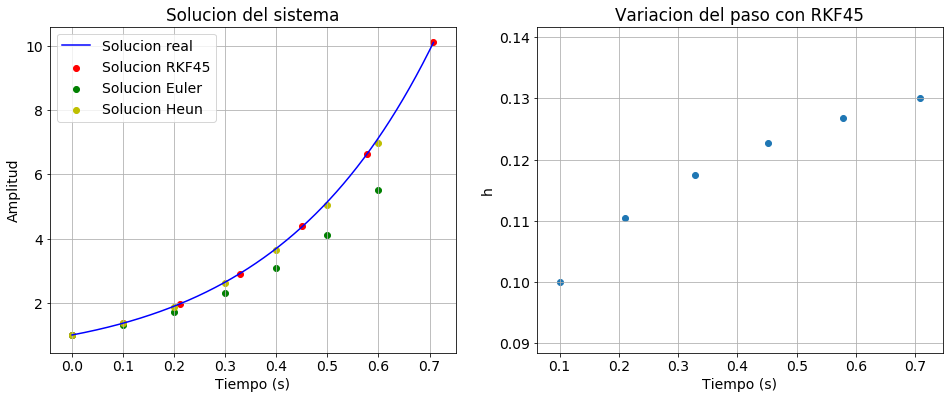

```python
""" Prueba con una EDO """

import matplotlib.pyplot as plt

def load_funcion_edo_test(tn, yn):
    return 3*yn+3*tn

plt.rcParams['figure.figsize'] = [16,6]
plt.rcParams.update({'font.size': 14})

t0 = 0
y0 = 1
tf = 0.6
h = 0.1
hmax = 0.3
rtol = 0.001
atol = 0.0001
sol_rkf45 = RKF45(load_funcion_edo_test, y0, t0, tf, h, hmax, rtol, atol)

y_heun = heun(to, h, 6, load_funcion_edo_test, y0)
y_euler = euler(to, h, 6, load_funcion_edo_test, y0)
t_heun = np.arange(t0, tf + 0.1*tf, h)

t_rk45 = sol_rkf45[0]
y_rk45 = sol_rkf45[1]

sol_time = np.linspace(t0, t_rk45[-1], 1000)
sol = np.exp(3*sol_time)*4/3 - sol_time - 1/3

fig, (ax1, ax2) = plt.subplots(1, 2)
ax1.set_title('Solucion del sistema')
ax1.scatter(t_rk45, y_rk45, label='Solucion RKF45', color='r')
ax1.scatter(t_heun, y_euler, label='Solucion Euler', color='g')
ax1.scatter(t_heun, y_heun, label='Solucion Heun', color='y')
ax1.plot(sol_time, sol, label='Solucion real', color='b')
ax1.set_xlabel('Tiempo (s)')
ax1.set_ylabel('Amplitud')
ax1.legend()
ax1.grid()

ax2.set_title('Variacion del paso con RKF45')
ax2.scatter(t_rk45[1:], np.diff(t_rk45))
ax2.set_xlabel('Tiempo (s)')
ax2.set_ylabel('h')
ax2.grid()
plt.show()
```

### Prueba de la función para un sistema de EDOs

Se prueba la función RKF45 para el ejercicio 7 de la guía 6, el cual ya se resolvió anteriormente mediante Heun y Euler.  
Nuevamente se puede observar que el resultado es muy cercano al real en cada paso, con lo cual se verfica en primer lugar que el método funciona, y además que se lo puede utilizar para obtener resultados precisos para sistemas complejos en todos los instantes de tiempo, y no solo los finales, como podría ocurrir con el método de Heun.  
Además, se muestra la variacion del paso h con el tiempo. Éste presenta un mínimo a los 750ms, por lo que se puede concluir que el sistema es *stiff* en un entorno de dicho valor temporal.

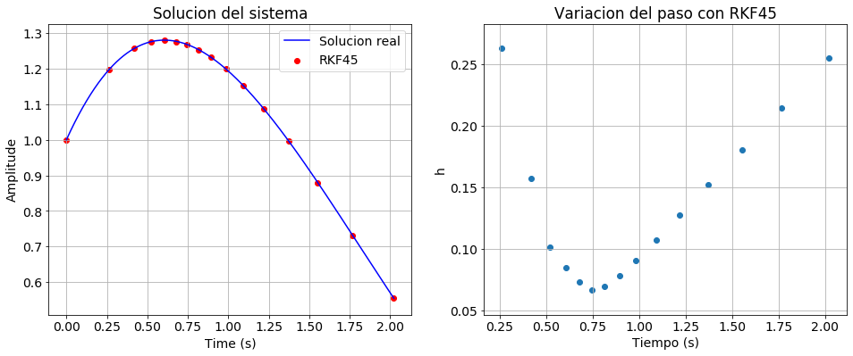

```python
""" Prueba con sistema de EDOs """

def load_funcion_sist_test(tn, yn):
    return np.asarray([-yn[0] - yn[1], yn[0]])

t0 = 0
tf = 2
y0 = [1, 1]
h = 0.5
hmax = 0.3
rtol = 0.001
atol = [0.0001, 0.0001]
sol_rkf45 = RKF45(load_funcion_sist_test, y0, t0, tf, h, hmax, rtol, atol)

t_rkf45 = sol_rkf45[0]
y_rkf45 = sol_rkf45[1]

time = np.linspace(t0, t_rkf45[-1], 1000)
sol = 2*np.exp(-time/2)*np.sin(3**0.5/2*time + np.pi/6)

fig, (ax1, ax2) = plt.subplots(1, 2)
ax1.scatter(t_rkf45, y_rkf45[:,1], label='RKF45', color='r')
ax1.plot(time, sol, label='Solucion real', color='b')
ax1.set_title('Solucion del sistema')
ax1.set_xlabel('Time (s)')
ax1.set_ylabel('Amplitude')
ax1.legend()
ax1.grid()

ax2.set_title('Variacion del paso con RKF45')
ax2.scatter(t_rkf45[1:], np.diff(t_rkf45))
ax2.set_xlabel('Tiempo (s)')
ax2.set_ylabel('h')
ax2.grid()
plt.show()
```

## Problema planteado

En los últimos años se ha estado avanzando en la antigua idea de transmitir energía de forma inalámbrica, en particular en la idea de transmitir información y energía juntas (SWIPT). Una aplicación particular puede ser el aprovechar las ondas electromagnéticas que ciruclan en el aire para transformarla en energía utilizable. En estos sistemas, se debe utilizar una antena para captar las ondas electromagnéticas.  
Se busca simular el comportamiento de un puente de diodos ante una entrada de alta frecuencia, para analizar el comportamiento al rectificar la señal proveniente de una antena. Para rectificar la señal se utiliza un puente de diodos Schottky, con una rápida respuesta transitoria por estar formados por una juntura metal-semiconductor que no acumula cargas del lado del metal, lo cual los hace ideales para una aplicación de alta frecuencia.  
El circuito es el siguiente:

[figure not shown]

La entrada al circuito viene dada por: \begin{equation} v_s(t) = A sin(2 \pi f t) \end{equation}

Se trabajará con una carga $R_L=50\Omega$. La amplitud de entrada es $A=2V$ y su frecuencia es $f = 2.45GHz$, ya que este tipo de sistemas trabaja con señales de este orden de frecuencia. Por ejemplo, en la referencia [3] de la consigna, obtuvieron energía de ondas con las siguientes características:

[figure not shown]

La menor frecuencia con la que se trabajó es de $0.8GHz$, por lo que tiene sentido trabajar con una frecuencia de $2.4GHz$

Si bien modelo de pequeñas señales de un diodo para bajas frecuencias es una resistencia, en este caso se debe trabajar con un modelo más completo, dado que en altas frecuencias tienen una gran influencia las capacidades e inductancias internas.  
El modelo equivalente utilizado para el diodo es el siguiente:

[figure not shown]

Los parámetros del modelo, correspondientes al diodo HSMS 2863, serán los siguientes:

| Parametro | Valor |
| --- | --- |
| $I{sat}$ | 50nA |
| $C_p$ | 0.08pF |
| $C_j$ | 0.18pF |
| $R_s$ | 5$\Omega$ |
| $L_p$ | 2nH |
| N | 1.08 |
| $V_T$ | 26mV |

El comportamiento del puente de diodos se puede modelar con el siguiente sistema de ecuaciones diferenciales:

\begin{align} \frac{dv^{(k)}_p}{dt} &= \frac{1}{C_p} \left( i^{k} + \frac{v^{(k)}_j - v^{(k)}_p}{R_s} \right) \\ \frac{dv^{(k)}_j}{dt} &= \frac{1}{C_j} \left( \frac{v^{(k)}_p - v^{(k)}_j}{R_s} - i_D(v^{(k)}_j) \right) \\ \frac{di^{(1)}}{dt} &= \frac{1}{L_s} \left( v_s - v_a - v^{(1)}_p \right) \\ \frac{di^{(2)}}{dt} &= \frac{1}{L_s} \left( - v_a - v^{(2)}_p \right) \\ \frac{di^{(3)}}{dt} &= \frac{1}{L_s} \left( v_b - v_s - v^{(3)}_p \right) \\ \frac{di^{(4)}}{dt} &= \frac{1}{L_s} \left( v_b - v^{(4)}_p \right) \end{align}

Donde $k = 1,2,3,4$ representa a cada diodo.  
Las tensiones $v_a$ y $v_b$ vienen dadas por: \begin{align} v_a &= v_b + R_L (i^{(1)} + i^{(2)}) \\ v_b &= \frac{v_s}{2} - \frac{R_L}{2} (i^{(1)} + i^{(2)}) + \frac{v^{(3)}_p + v^{(4)}_p - v^{(1)}_p - v^{(2)}_p }{4} \end{align}

Por último, conociendo las corrientes de que circula por las inductancias se puede conocer la corriente a la salida y calcular la tensión de salida mediante:

\begin{equation} v_o = (i^{(1)} + i^{(2)}) \cdot R_L \end{equation}

### Simulacion inicial

En primer lugar, se muestra el comportamiento del sistema para el marco planteado simulando con el método RKF45 y se analizan los resultados.

```python
""" SIMULACION DEL CIRCUITO """

import warnings
warnings.filterwarnings("ignore")

""" Tension de entrada """
def vs(t):
    return A*np.sin(2*np.pi*f*t)

""" Corriente de un diodo """
def I_d(vj):
    return Isat*(np.exp(vj / (nu*Vt)) - 1)

""" Tensiones auxiliares"""
def va(tn, yn):
    return vb(tn, yn) + Rl*(yn[8] + yn[9])

def vb(tn, yn):
    return vs(tn)/2.0 - (Rl/2.0) * (yn[8]+yn[9]) + (yn[2]+yn[3]-yn[0]-yn[1]) / 4.0

"""
  Indices de las magnitudes dentro de yn:
    vp: [0, 3]
    vj: [4, 7]
    i:  [8, 11]
"""

""" Magnitudes buscadas """
def dv_p(tn, yn):
    return [ (yn[8+k] + (yn[4+k] - yn[k]) / Rs) / Cp  for k in range(4) ]

def dv_j(tn, yn):
    return [ ((1.0/Rs) * (yn[0+k]-yn[4+k]) - I_d(yn[4+k])) / Cj for k in range(4)]

def di1(tn, yn):
    return (vs(tn) - va(tn,yn) - yn[0]) / Ls

def di2(tn, yn):
    return ( -va(tn,yn) - yn[1]) / Ls

def di3(tn, yn):
    return (vb(tn,yn) - vs(tn) - yn[2]) / Ls

def di4(tn, yn):
    return (vb(tn,yn) - yn[3])/Ls


def diodes_load_function(tn, yn):
    ret = []
    # dvp/dt de cada diodo
    ret = np.append(ret, dv_p(tn, yn))

    # dvj/dt de cada diodo
    ret = np.append(ret, dv_j(tn, yn))

    # di1/dt
    ret = np.append(ret, di1(tn, yn))

    # di2/dt
    ret = np.append(ret, di2(tn, yn))

    # di3/dt
    ret = np.append(ret, di3(tn, yn))

    # di4/dt
    ret = np.append(ret, di4(tn, yn))

    return ret


# Parametros fisicos de los componentes
Isat = 50e-9
Cp = 0.08e-12
Cj = 0.18e-12
Rs = 5
Ls = 2e-9
nu = 1.08
Vt = 26e-3
Rl = 50

# Parámetros de la entrada del circuito
f = 2.45e9
A = 2

# Pasos para la simulacion
hinit = 1e-13

# si f=2.45GHz, un periodo son 408us, como maximo lo dejamos avanzar de a 1/100 periodos
hmax = 4e-12

# Tolerancias
atol = np.zeros(12)
atol.fill(1e-9)
rtol = 1e-3

# Condiciones iniciales y tiempo final
t0 = 0
tf = 1.5e-9
y0 = np.zeros(12)

# Simulamos
time_first, y_first = RKF45(diodes_load_function, y0, t0, tf, hinit, hmax, rtol, atol)
```

```python
def calculate_output(t, diodes_currents):
    # vo = (i1 + i2) * RL
    vo = (diodes_currents[:,0] + diodes_currents[:,1]) * Rl
    return vo

def calculate_input(time):
    return [vs(t) for t in time]


# Interpretamos los valores de la salida
voltages_p = y_first[:,0:4]
voltages_junction = y_first[:,4:8]
diodes_currents = y_first[:,8:12]

# Calculamos la tension de salida
v_out = calculate_output(time_first, diodes_currents)

# Calculamos la tension de entrada
v_in = calculate_input(time_first)
```

Magnitudes del sistema

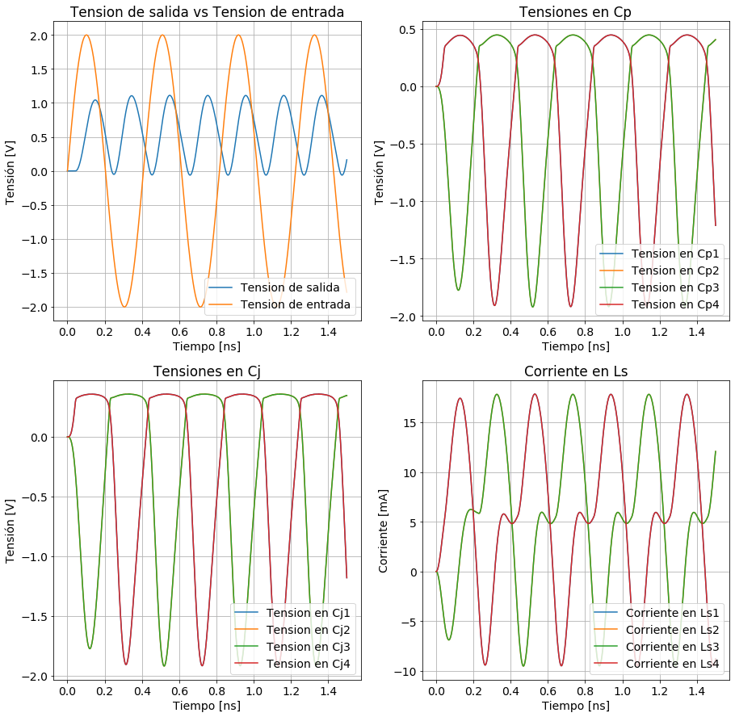

```python
from IPython.core.display import display, HTML
from copy import copy

# Configuración de tamaño para Matplotlib
plt.rcParams['figure.figsize'] = [15, 15]

def plot_result(time, voltages_p, voltages_junction, currents, v_in, v_out):

    # Pasamos a ns
    t = copy(time) * 1e9

    # Pasamos a mA
    diodes_currents = copy(currents) * 1e3

    # Graficando
    fig1, ( (ax1, ax2), (ax3, ax4) ) = plt.subplots(2, 2)

    ax1.set_title('Tension de salida vs Tension de entrada')
    ax1.set_xlabel('Tiempo [ns]')
    ax1.set_ylabel('Tensión [V]')
    ax1.grid()

    ax2.set_title('Tensiones en Cp')
    ax2.set_xlabel('Tiempo [ns]')
    ax2.set_ylabel('Tensión [V]')
    ax2.grid()

    ax3.set_title('Tensiones en Cj')
    ax3.set_xlabel('Tiempo [ns]')
    ax3.set_ylabel('Tensión [V]')
    ax3.grid()

    ax4.set_title('Corriente en Ls')
    ax4.set_xlabel('Tiempo [ns]')
    ax4.set_ylabel('Corriente [mA]')
    ax4.grid()

    display(HTML(f'<h2 style="text-align: center;"> Magnitudes del sistema </h2>'))

    # Tension de salida
    ax1.plot(t, v_out, label='Tension de salida')
    ax1.plot(t, v_in, label='Tension de entrada')

    # Para cada diodo
    for k in range(4):
        # Graficamos la tension en Cp
        ax2.plot(t, voltages_p[:,k], label=f'Tension en Cp{k + 1}')

        # Graficamos la tension en Cj
        ax3.plot(t, voltages_junction[:,k], label=f'Tension en Cj{k + 1}')

        # Graficamos la corriente del diodo
        ax4.plot(t, diodes_currents[:,k], label=f'Corriente en Ls{k + 1}')

    ax1.legend(loc='lower right')
    ax2.legend(loc='lower right')
    ax3.legend(loc='lower right')
    ax4.legend(loc='lower right')
    plt.show()

plot_result(time_first, voltages_p, voltages_junction, diodes_currents, v_in, v_out)
```

Los resultados observados son razonables: la tensión de salida es positiva y menor a la tension de entrada debido a la caída de tensión en los diodos. Además, se observa un desfasaje entre la entrada y la salida debido a la presencia de los componentes reactivos, es decir, inductancias y capacitores.

Para verificar que los cálculos fueran correctos, se simuló el circuito propuesto en LTSpice para comparar los resultados. A continuación se muestra la superposición de las tensiones y corrientes calculadas con las simuladas. Por la simetría del circuito, las corrientes y tensiones son iguales en los diodos 1 y 4, y en el 2 y el 3, por lo que solo se comparan las tensiones y corrientes de los diodos 1 y 2.

Magnitudes del sistema calculadas y simuladas

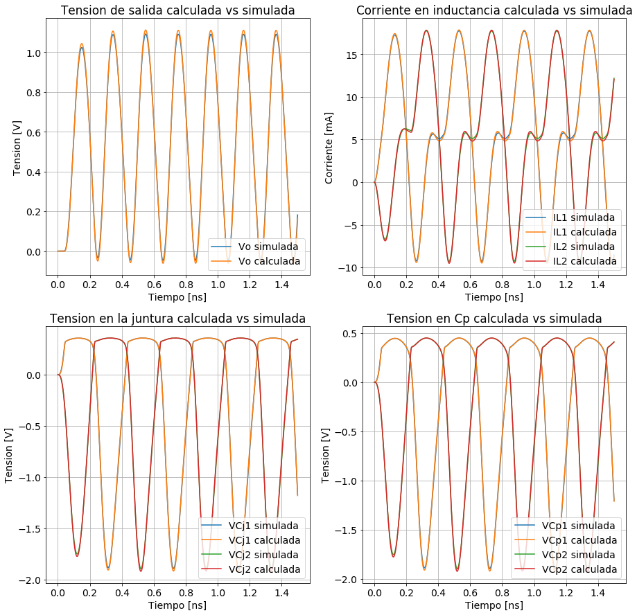

```python
# Configuración de tamaño para Matplotlib
plt.rcParams['figure.figsize'] = [15, 15]

def read_LTSpice(filename):
    """ Lee un archivo de LTSpice con una magnitud en funcion del tiempo """
    simulation_file = open(filename, "r")
    lines = simulation_file.readlines()
    test = lines[0].split()
    # Numero de magniutdes a la salida es la cantidad de columnas menos la del tiempo
    y_count = len(test) - 1
    del lines[0]  # Throw away the first line, labels of the columns
    t = np.zeros(len(lines))
    y = np.zeros( (len(lines), y_count) )
    for k in range(len(lines)):
        temp = lines[k].split()
        t[k] = temp[0]
        for i in range(1, len(temp)):
            y[k][i - 1] = temp[i]
    return t, y


def plot_comparison(ax, mag_name, mag_short, sim_time, sim_mags, calc_time, calc_mags, x_label, mul_x, y_label, mul_y):
    """ Grafica la comparacion. Recibe mul_x y mul_y para escalar los ejes de tiempo sin modificar los datos de entrada """

    # Graficando
    ax.set_title( f'{mag_name} calculada vs simulada')
    ax.set_xlabel(x_label)
    ax.set_ylabel(y_label)

    # Para cada diodo
    for k in range(len(calc_mags[0])):
        # Graficamos magnitud simulada
        label = f'{mag_short}{k+1}' if len(calc_mags[0]) > 1 else mag_short
        ax.plot(sim_time * mul_x, sim_mags[:,k] * mul_y, label=label + ' simulada')

        # Graficamos magnitud calculada
        ax.plot(calc_time * mul_x, calc_mags[:,k] * mul_y, label=label + ' calculada' )

    ax.legend(loc='lower right')
    ax.grid()

fig, ((ax1, ax2), (ax3, ax4)) = plt.subplots(2, 2)

display(HTML(f'<h2 style="text-align: center;"> Magnitudes del sistema calculadas y simuladas </h2>'))

# Tension de salida
sim_time, sim_out = read_LTSpice('vo_LTSpice.txt')
plot_comparison(ax1, 'Tension de salida', 'Vo', sim_time, sim_out, time_first, np.asarray([[v] for v in v_out]), 'Tiempo [ns]', 1e9, 'Tension [V]', 1)

# Corriente en los inductores
sim_time, sim_out = read_LTSpice('il_LTSpice.txt')
plot_comparison(ax2, 'Corriente en inductancia', 'IL', sim_time, sim_out, time_first, diodes_currents[:,0:2], 'Tiempo [ns]', 1e9, 'Corriente [mA]', 1e3)

# Tension en junturas
sim_time, sim_out = read_LTSpice('vcj_LTSpice.txt')
plot_comparison(ax3, 'Tension en la juntura', 'VCj', sim_time, sim_out, time_first, voltages_junction[:,0:2], 'Tiempo [ns]', 1e9, 'Tension [V]', 1)

# Tension en Cp
sim_time, sim_out = read_LTSpice('vcp_LTSpice.txt')
plot_comparison(ax4, 'Tension en Cp', 'VCp', sim_time, sim_out, time_first, voltages_p[:,0:2], 'Tiempo [ns]', 1e9, 'Tension [V]', 1)

plt.show()
```

En todos los casos las magnitudes tienen un alto grado de coincidencia, con lo que se concluye que los cálculos son correctos.

Notar que la tensión de salida tiene una respuesta transitoria, dado que se mantiene en 0 durante los primeros $ps$ y en el primer período tiene una amplitud menor a la amplitud de los siguientes períodos. Al variar el valor de $L_s$ variará la duración de esta respuesta transitoria y hay que tener en cuenta su presencia para analizar parámetros de la tensión de salida.

### Variacion de Ls

```python
# Pasos para la simulacion
hinit = 1e-13

# si f=2.45GHz, un periodo son 408us, como maximo lo dejamos avanzar de a 1/100 periodos
hmax = 4e-12

# Tolerancias
atol = np.zeros(12)
atol.fill(1e-7)
rtol = 1e-3

# Condiciones iniciales y tiempo final
t0 = 0
tf = 3e-9
y0 = np.zeros(12)

Ls = 10e-12

time_ls = []
outputs_ls = []

for k in range(7):
    # Simulamos
    t_aux, y_aux = RKF45(diodes_load_function, y0, t0, tf, hinit, hmax, rtol, atol)
    time_ls.append(t_aux)
    curr = y_aux[:,8:12]
    out = calculate_output(t_aux, curr)
    outputs_ls.append(out)
    Ls = 10**0.5 * Ls
```

```python
""" Funciones para visualizacion de datos en tabla HTML """

from IPython.core.display import display, HTML

def get_order(x):
    ret = (' ', 1)
    if x >= 1e9 - 1e8:
        ret = ('G', 1e-9)
    elif x >= 1e6 - 1e5:
        ret = ('M', 1e-6)
    elif x >= 1e3 - 1e2:
        ret = ('k', 1e-3)
    elif x >= 1e0 - 1e-1:
        ret = (' ', 1)
    elif x >= 1e-3 - 1e-4:
        ret = ('m', 1e3)
    elif x >= 1e-6 - 1e-7:
        ret = ('u', 1e6)
    elif x >= 1e-9 - 1e-10:
        ret = ('n', 1e9)
    elif x >= 1e-12 - 1e-13:
        ret = ('p', 1e12)

    return ret


def make_row(cells):
    ret = '<tr>'
    for cell in cells:
        ret += f'<td style="text-align:center">{cell}</td>'
    ret += '</tr>'
    return ret

def make_header(cols):
    ret = '<table style="border:1px solid black;margin-left:auto;margin-right:auto;"><thead><tr>'
    for col in cols:
        ret += f'<th style="text-align:center">{col}</th>'
    ret += '</tr></thead><tbody>'
    return ret
```

Parámetros de la tensión de salida variando Ls

| Ls | Vmin | Vmax | V | Vrms |
| --- | --- | --- | --- | --- |
| 10.0pH | 0.012V | 1.061V | 0.498V | 0.643V |
| 31.6pH | 0.011V | 1.064V | 0.520V | 0.661V |
| 100.0pH | 0.008V | 1.076V | 0.534V | 0.674V |
| 316.2pH | -0.008V | 1.083V | 0.535V | 0.683V |
| 1.0nH | -0.060V | 1.014V | 0.525V | 0.651V |
| 3.2nH | 0.042V | 1.136V | 0.602V | 0.710V |
| 10.0nH | 0.337V | 0.631V | 0.476V | 0.486V |

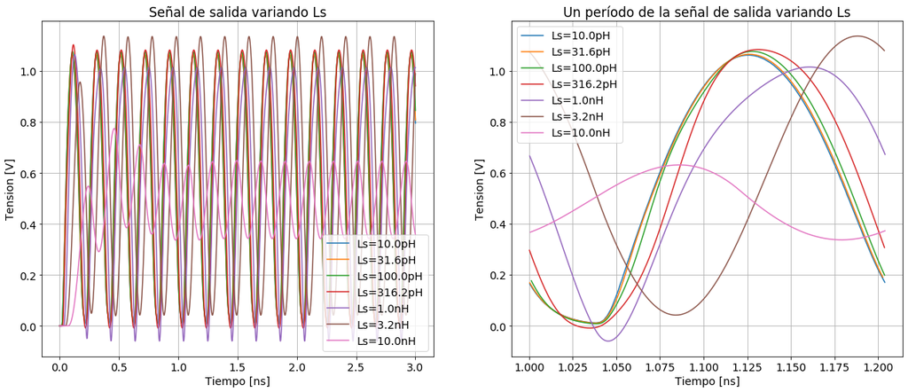

```python
# Configuración de tamaño para Matplotlib
plt.rcParams['figure.figsize'] = [20, 8]


""" Devuelve un periodo de la señal en estado estacionario """
def get_one_period(t_stat, period, time, x):
    # Obtenemos el primer valor donde supere el tiempo estacinario
    init_index = np.argwhere( time > t_stat)[0][0]

    # Buscamos un periodo mas adelante
    final_index = np.argwhere( time < (t_stat + period) )[-1][0]

    return (time[init_index:final_index+1], x[init_index:final_index+1])


html_table = make_header(['Ls', 'Vmin', 'Vmax', '<span style="text-decoration:overline">V</span>', 'Vrms'])

Ls_aux = 10e-12

fig, (ax2, ax1) = plt.subplots(1, 2)

ax1.set_title('Un período de la señal de salida variando Ls')
ax1.set_xlabel('Tiempo [ns]')
ax1.set_ylabel('Tension [V]')

ax2.set_title('Señal de salida variando Ls')
ax2.set_xlabel('Tiempo [ns]')
ax2.set_ylabel('Tension [V]')


for k in range(7):
    t_aux, y_aux = get_one_period(1e-9, 1/(2*f), time_ls[k], outputs_ls[k])
    vmin = np.min(y_aux)
    vmax = np.max(y_aux)
    vmed = np.mean(y_aux)
    vrms = np.mean(np.power(y_aux, 2))**0.5
    sufix, mul =  get_order(Ls_aux)
    html_table += make_row([f'{Ls_aux*mul:.1f}{sufix}H', f'{vmin:.3f}V', f'{vmax:.3f}V', f'{vmed:.3f}V', f'{vrms:.3f}V'])
    label = f'Ls={Ls_aux*mul:.1f}{sufix}H'
    ax1.plot(t_aux * 1e9, y_aux, label=label)
    ax2.plot(time_ls[k] * 1e9, outputs_ls[k], label=label)
    Ls_aux *= 10**0.5

html_table += '</tbody></table>'

display(HTML('<h1 style="text-align: center;"> Parámetros de la tensión de salida variando Ls </h1>'))
display(HTML(html_table))
ax1.grid()
ax1.legend()
ax2.grid()
ax2.legend(loc='lower right')
plt.show()
```

El caso con respuesta transitoria más larga es el de $L_s = 10nH$, lo cual tiene sentido porque las inductancias intentan bloquear las altas frecuencias, con lo que a mayor inductancia mayor oposición a cambios bruscos.

Considerando que a partir de $1ns$ todas las salidas están en estado estacionario, se calcularon las tensiones mínima, máxima, media y cuadrática media para la tensión de salida con cada $L_s$ en estado estacionario. Para ello se tomó un período de la señal de salida, que corresponde a medio período de la señal de entrada.

### Variacion de Rs

Ahora se varía la resistencia interna $R_s$ entre $1\Omega$ y $10\Omega$, con un paso de $1\Omega$.

```python
# Pasos para la simulacion
hinit = 1e-13

# si f=2.45GHz, un periodo son 408us, como maximo lo dejamos avanzar de a 1/100 periodos
hmax = 4e-12

# Tolerancias
atol = np.zeros(12)
atol.fill(1e-7)
rtol = 1e-3

# Condiciones iniciales y tiempo final
t0 = 0
tf = 1.5e-9
y0 = np.zeros(12)

Ls = 2e-9
Rs = 1

time_rs = []
outputs_rs = []

for k in range(10):
    # Simulamos
    t_aux, y_aux = RKF45(diodes_load_function, y0, t0, tf, hinit, hmax, rtol, atol)
    time_rs.append(t_aux)
    curr = y_aux[:,8:12]
    out = calculate_output(t_aux, curr)
    outputs_rs.append(out)
    Rs += 1
```

Parámetros de la tensión de salida variando Rs

| Rs | Vmin | Vmax | V | Vrms |
| --- | --- | --- | --- | --- |
| 1Ω | -0.065V | 1.228V | 0.607V | 0.756V |
| 2Ω | -0.064V | 1.197V | 0.575V | 0.725V |
| 3Ω | -0.063V | 1.167V | 0.547V | 0.697V |
| 4Ω | -0.062V | 1.138V | 0.528V | 0.677V |
| 5Ω | -0.061V | 1.110V | 0.530V | 0.670V |
| 6Ω | -0.060V | 1.083V | 0.490V | 0.637V |
| 7Ω | -0.060V | 1.058V | 0.491V | 0.625V |
| 8Ω | -0.058V | 1.033V | 0.498V | 0.633V |
| 9Ω | -0.058V | 1.009V | 0.523V | 0.633V |
| 10Ω | -0.057V | 0.986V | 0.504V | 0.616V |

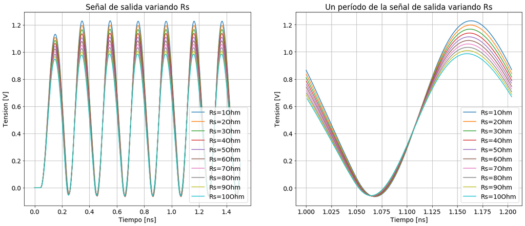

```python
# Configuración de tamaño para Matplotlib
plt.rcParams['figure.figsize'] = [20, 8]


html_table = make_header(['Rs', 'Vmin', 'Vmax', '<span style="text-decoration:overline">V</span>', 'Vrms'])

fig, (ax2, ax1) = plt.subplots(1, 2)

ax1.set_title('Un período de la señal de salida variando Rs')
ax1.set_xlabel('Tiempo [ns]')
ax1.set_ylabel('Tension [V]')

ax2.set_title('Señal de salida variando Rs')
ax2.set_xlabel('Tiempo [ns]')
ax2.set_ylabel('Tension [V]')

Rs_aux = 1

for k in range(10):
    t_aux, y_aux = get_one_period(1e-9, 1/(2*f), time_rs[k], outputs_rs[k])
    vmin = np.min(y_aux)
    vmax = np.max(y_aux)
    vmed = np.mean(y_aux)
    vrms = np.mean(np.power(y_aux, 2))**0.5
    html_table += make_row([f'{Rs_aux}Ω', f'{vmin:.3f}V', f'{vmax:.3f}V', f'{vmed:.3f}V', f'{vrms:.3f}V'])
    label = f'Rs={Rs_aux}Ohm'
    ax1.plot(t_aux * 1e9, y_aux, label=label)
    ax2.plot(time_rs[k] * 1e9, outputs_rs[k], label=label)
    Rs_aux += 1

html_table += '</tbody></table>'

display(HTML('<h1 style="text-align: center;"> Parámetros de la tensión de salida variando Rs </h1>'))
display(HTML(html_table))
ax1.grid()
ax1.legend()
ax2.grid()
ax2.legend(loc='lower right')
plt.show()
```

Se observa que al aumentar $R_s$, disminuye la tensión máxima de salida, lo cual era de esperarse ya que cae mayor tensión en cada diodo. Dado que no se modificó el valor de ningún componente reactivo, no cambia el desfasaje temporal introducido por el sistema.

### Variacion de la frecuencia

Por último, se varía la frecuencia de entrada entre $1GHz$ y $10GHz$, con un paso de $1GHz$.

```python
# Pasos para la simulacion
hinit = 1e-13

hmax = 4e-12

# Tolerancias
atol = np.zeros(12)
atol.fill(1e-7)
rtol = 1e-3

# Condiciones iniciales y tiempo final
t0 = 0
tf = 2e-9
y0 = np.zeros(12)

Rs = 5
f = 1e9

time_f = []
outputs_f = []

for k in range(10):
    # Simulamos
    t_aux, y_aux = RKF45(diodes_load_function, y0, t0, tf, hinit, hmax, rtol, atol)
    time_f.append(t_aux)
    curr = y_aux[:,8:12]
    out = calculate_output(t_aux, curr)
    outputs_f.append(out)
    f += 1e9
```

Parámetros de la tensión de salida variando f

| f | Vmin | Vmax | V | Vrms |
| --- | --- | --- | --- | --- |
| 1.0GHz | -0.085V | 0.995V | 0.560V | 0.672V |
| 2.0GHz | -0.020V | 0.998V | 0.533V | 0.640V |
| 3.0GHz | 0.012V | 1.205V | 0.603V | 0.731V |
| 4.0GHz | 0.335V | 1.459V | 0.889V | 0.958V |
| 5.0GHz | 0.581V | 1.493V | 1.002V | 1.037V |
| 6.0GHz | 0.583V | 1.188V | 0.876V | 0.894V |
| 7.0GHz | 0.475V | 0.845V | 0.668V | 0.676V |
| 8.0GHz | 0.362V | 0.587V | 0.482V | 0.487V |
| 9.0GHz | 0.269V | 0.407V | 0.348V | 0.350V |
| 10.0GHz | 0.196V | 0.282V | 0.249V | 0.250V |

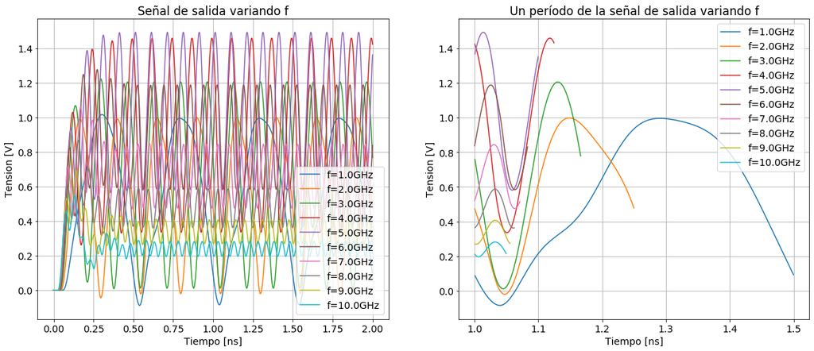

```python
# Configuración de tamaño para Matplotlib
plt.rcParams['figure.figsize'] = [20, 8]


html_table = make_header(['f', 'Vmin', 'Vmax', '<span style="text-decoration:overline">V</span>', 'Vrms'])

fig, (ax2, ax1) = plt.subplots(1, 2)

ax1.set_title('Un período de la señal de salida variando f')
ax1.set_xlabel('Tiempo [ns]')
ax1.set_ylabel('Tension [V]')

ax2.set_title('Señal de salida variando f')
ax2.set_xlabel('Tiempo [ns]')
ax2.set_ylabel('Tension [V]')

f_aux = 1e9

for k in range(10):
    t_aux, y_aux = get_one_period(1e-9, 1/(2*f_aux), time_f[k], outputs_f[k])
    vmin = np.min(y_aux)
    vmax = np.max(y_aux)
    vmed = np.mean(y_aux)
    vrms = np.mean(np.power(y_aux, 2))**0.5
    sufix, mul =  get_order(f_aux)
    label = f'f={f_aux*mul:.1f}{sufix}Hz'
    html_table += make_row([f'{f_aux*mul:.1f}{sufix}Hz', f'{vmin:.3f}V', f'{vmax:.3f}V', f'{vmed:.3f}V', f'{vrms:.3f}V'])
    ax1.plot(t_aux * 1e9, y_aux, label=label)
    ax2.plot(time_f[k] * 1e9, outputs_f[k], label=label)
    f_aux += 1e9

html_table += '</tbody></table>'

display(HTML('<h1 style="text-align: center;"> Parámetros de la tensión de salida variando f </h1>'))
display(HTML(html_table))
ax1.grid()
ax1.legend()
ax2.grid()
ax2.legend(loc='lower right')
plt.show()
```

Para este ultimo caso, logicamente, cambia la frecuencia a la salida, siempre es el doble de la frecuencia de entrada. En todos los casos luego de $1ns$ se está en estado estacionario, por lo que se toma un período a partir de allí para calcular los parámetros buscados. En este caso el intervalo de tiempo tomado cambia para las distintas salidas, ya que tienen diferentes períodos.